# Markov Chain Monte Carlo Diagnostics

# 6 Demonstration

Now let’s put all of these analysis tools to use with an `PyStan` fit object.

First we setup our local `Python` environment.

```python
import matplotlib
import matplotlib.pyplot as plot
plot.show()
plot.rcParams['figure.figsize'] = [6, 4]
plot.rcParams['figure.dpi'] = 100
plot.rcParams['font.family'] = "Serif"

light="#DCBCBC"
light_highlight="#C79999"
mid="#B97C7C"
mid_highlight="#A25050"
dark="#8F2727"
dark_highlight="#7C0000"

import numpy

import pystan

import multiprocessing
multiprocessing.set_start_method("fork")
```

Next we source all of these diagnostics into a local namespace to avoid any conflicts with other functions.

```python
import stan_utility_pystan2 as util
```

Then we can simulate some binary data from a logistic regression model.

```
simu\_logistic\_reg.stan
```

```stan
transformed data {
  int<lower=0> M = 3;         // Number of covariates
  int<lower=0> N = 1000;      // Number of observations

  vector[M] x0 = [-1, 0, 1]'; // Covariate baseline
  vector[M] z0 = [-3, 1, 2]'; // Latent functional behavior baseline
  real gamma0 = -2.6;                      // True intercept
  vector[M] gamma1 = [0.2, -2.0, 0.33]';   // True slopes
  matrix[M, M] gamma2 = [ [+0.40, -0.05, -0.20],
                          [-0.05, -1.00, -0.05],
                          [-0.20, -0.05, +0.50] ];
}

generated quantities {
  matrix[N, M] X; // Covariate design matrix
  real y[N];      // Variates

  for (n in 1:N) {
    real x2 = -5;
    while (x2 < x0[2] - 4 || x2 > x0[2] + 4)
      x2 = normal_rng(x0[2], 2);

    X[n, 2] = x2;
    X[n, 1] = normal_rng(x0[1] + 1.0 * cos(1.5 * (X[n, 2] - x0[2])), 0.3);
    X[n, 3] = normal_rng(x0[3] + 0.76 * (X[n, 1] - x0[1]), 0.5);

    y[n] = bernoulli_logit_rng(  gamma0
                               + (X[n] - z0') * gamma1
                               + (X[n] - z0') * gamma2 * (X[n] - z0')');
  }
}
```

```python
model = util.compile_model('stan_programs/simu_logistic_reg.stan')
simu = model.sampling(iter=1, warmup=0, chains=1, chain_id=[1],
                      refresh=1000, seed=4838282,
                      algorithm="Fixed_param")

X = simu.extract()['X'][0]
y = simu.extract()['y'][0].astype(numpy.int64)

data = dict(M = 3, N = 1000, x0 = [-1, 0, 1], X = X, y = y)
```

We’ll try to fit this model not with a constraint-respecting logistic regression model but rather a constraint blaspheming linear probability model. Importantly the resulting posterior density function is discontinuous with configurations `alpha + deltaX * beta > 0` resulting in finite `bernoulli_lpmf` outputs and those with `alpha + deltaX * beta <= 0` resulting in minus infinite outputs.

```
bernoulli\_linear.stan
```

```stan
data {
  int<lower=0> M; // Number of covariates
  int<lower=0> N; // Number of observations

  vector[M] x0;   // Covariate baselines
  matrix[N, M] X; // Covariate design matrix

  int<lower=0, upper=1> y[N]; // Variates
}

transformed data {
  matrix[N, M] deltaX;
  for (n in 1:N) {
    deltaX[n,] = X[n] - x0';
  }
}

parameters {
  real alpha;      // Intercept
  vector[M] beta;  // Linear slopes
}

model {
  // Prior model
  alpha ~ normal(0, 1);
  beta ~ normal(0, 1);

  // Vectorized observation model
  y ~ bernoulli(alpha + deltaX * beta);
}

// Simulate a full observation from the current value of the parameters
generated quantities {
  vector[N] p = alpha + deltaX * beta;
  int y_pred[N] = bernoulli_rng(p);
}
```

Because of this awkward constraint we have to carefully initialize our Markov chains to satisfy the `alpha + deltaX * beta > 0` constraint.

```python
import scipy.stats as stats
numpy.random.seed(seed=48383499)

interval_inits = [None] * 4

for c in range(4):
  beta = [0, 0, 0]
  alpha = stats.norm.rvs(0.5, 0.1, size=1)[0]
  interval_inits[c] = dict(alpha = alpha, beta = beta)
```

```python
model = util.compile_model('stan_programs/bernoulli_linear.stan')
fit = model.sampling(data=data, seed=8438338, warmup=1000, iter=2024,
                     chain_id=[1, 2, 3, 4], refresh=0,
                     init=interval_inits)
```

Stan is able to run to completion, but just how useful are the Markov chains that it generates?

Let’s start with the Hamiltonian Monte Carlo diagnostics.

```python
diagnostics = util.extract_hmc_diagnostics(fit)
util.check_all_hmc_diagnostics(diagnostics)
```

[output not shown]

Almost every transition across the four Markov chains resulted in a divergence. This is due to the discontinuity in the linear probability model as the sudden jump from a finite to a negative infinite target density results in unstable numerical trajectories.

We also see the one of the Markov chains wasn’t quite able to hit the step size adaptation target. To see why let’s dig into the adapted configuration of the Hamiltonian Markov transition.

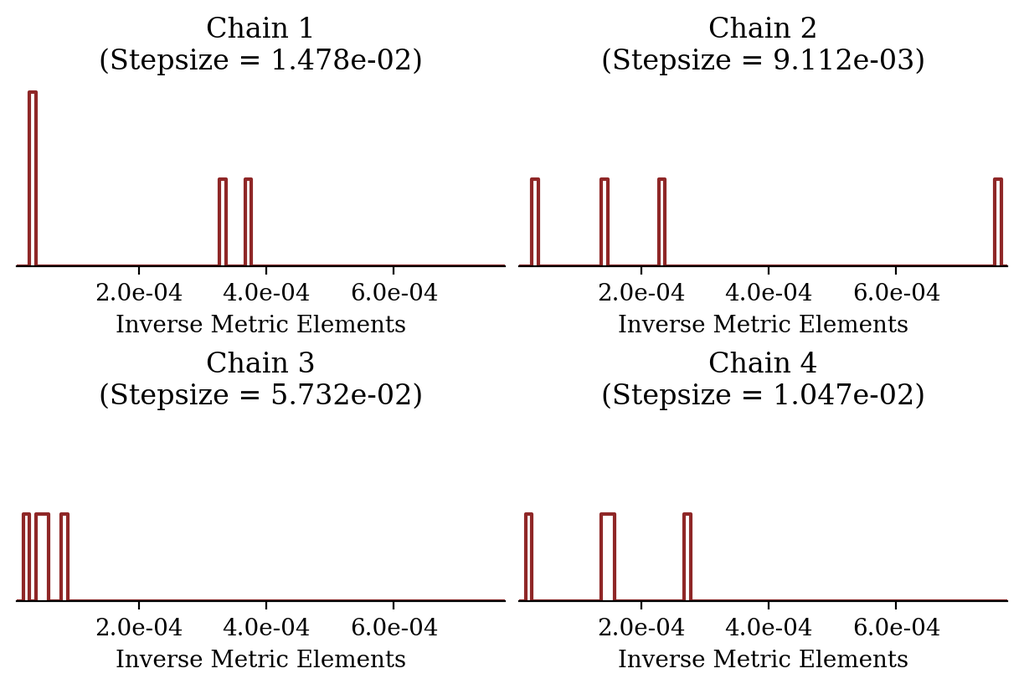

```python
util.plot_inv_metric(fit, 75)
```

The problematic third Markov chain also exhibits the least variation in its inverse metric elements, which in this case is probably an artifact of its warmup phase spending too much time close to a constraint boundary. Inverse metric elements that cannot adapt to each parameter can frustrate numerical integration which can then frustrate the integrator step size adaptation.

```python
util.display_stepsizes(diagnostics)
```

```python
util.display_ave_accept_proxy(diagnostics)
```

The different inverse metric results in different Hamiltonian dynamics. In this case the dynamics driving the third Markov chain are not able to explore as far as those in the other chains.

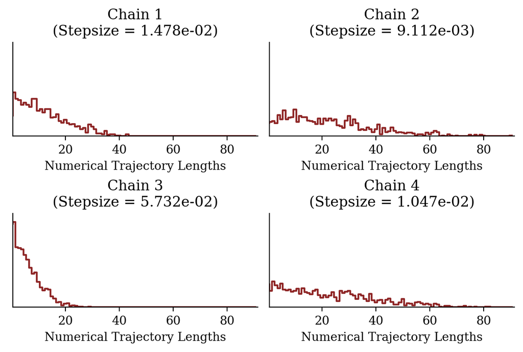

```python
util.plot_num_leapfrogs_by_chain(diagnostics)
```

Finally because nearly every transition is divergent we can’t extract much information from the divergent-labeled pairs plots.

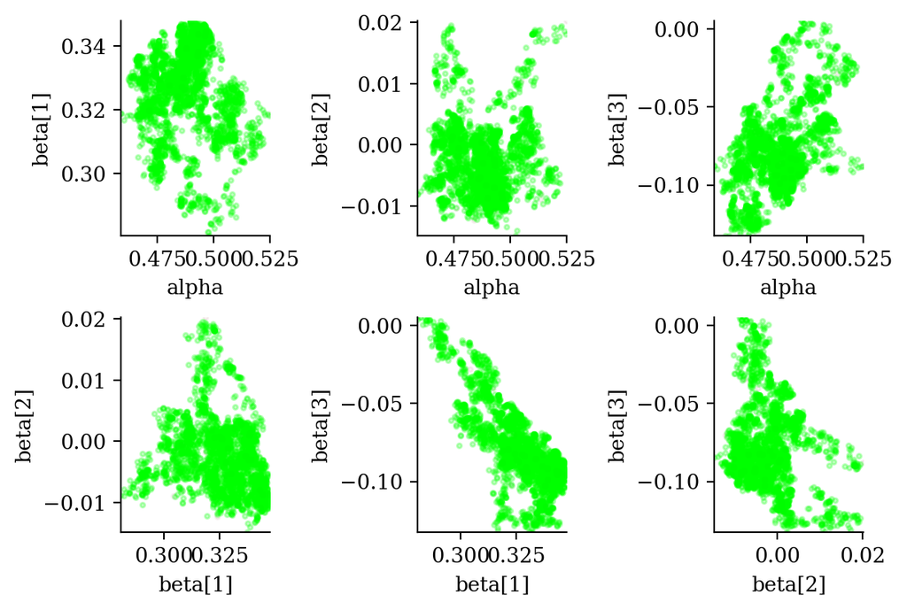

```python
samples = util.extract_expectands(fit)

names = ['alpha']
names += [ f'beta[{m + 1}]' for m in range(data['M']) ]
util.plot_div_pairs(names, names, samples, diagnostics)
```

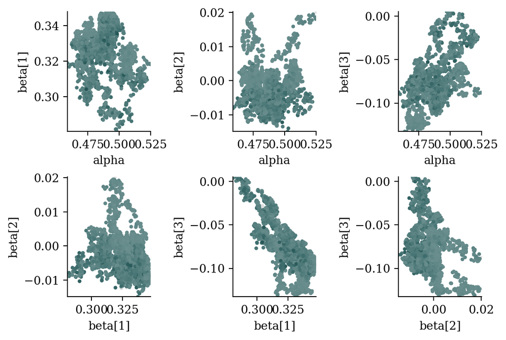

```python
util.plot_div_pairs(names, names, samples, diagnostics, plot_mode=1)
```

Having examined the Hamiltonian Monte Carlo diagnostics let’s now look through the expectand specific diagnostics. By default we’ll look at the parameter projection functions as well as all of the expectands defined in the `generated quantities` block.

Because of the Hamiltonian Monte Carlo diagnostic failures let’s start by looking at the expectand diagnostics summary instead of the full details.

```python
util.summarize_expectand_diagnostics(samples)
```

[output not shown]

[output cut: 496 more lines]

[output not shown]

That is a lot of diagnostic failures. To avoid overwhelming ourselves with too many detailed diagnostic messages let’s focus on the four parameter expectands.

```python
base_samples = util.filter_expectands(samples, ['alpha', 'beta'], True)
util.check_all_expectand_diagnostics(base_samples)
```

```
alpha:
  Split hat{R} (1.246) exceeds 1.1!

beta[1]:
  Split hat{R} (2.010) exceeds 1.1!

beta[2]:
  Split hat{R} (1.409) exceeds 1.1!

beta[3]:
  Split hat{R} (1.628) exceeds 1.1!


Split Rhat larger than 1.1 suggests that at least one of the Markov
chains has not reached an equilibrium.

Small empirical effective sample sizes indicate strong empirical
autocorrelations in the realized Markov chains. If the empirical
effective sample size is too small then Markov chain Monte Carlo
estimation may be unreliable even when a central limit theorem holds.
```

Motivated by the small effective sample size estimates let’s look at the empirical correlograms for each parameter expectand.

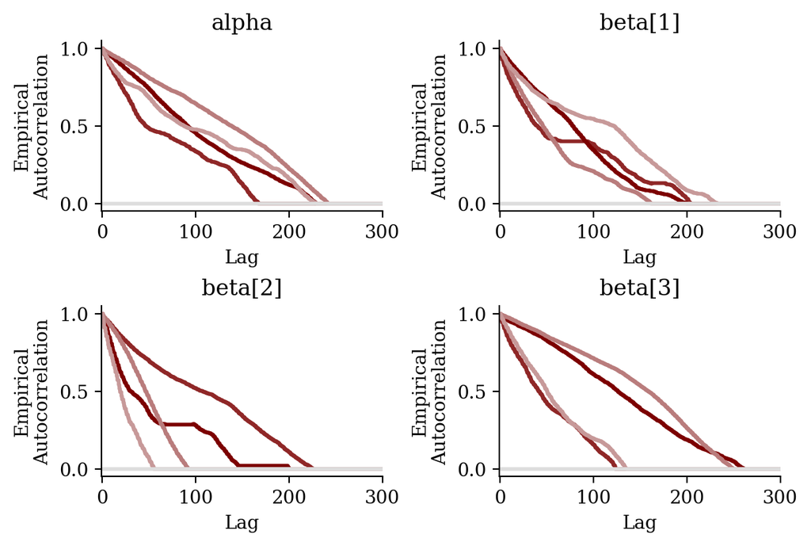

```python
f, axarr = plot.subplots(2, 2, layout="constrained")

util.plot_empirical_correlogram(axarr[0, 0], samples['alpha'],
                                300, [-0.05, 1.05],  'alpha')
util.plot_empirical_correlogram(axarr[0, 1], samples['beta[1]'],
                                300, [-0.05, 1.05],  'beta[1]')
util.plot_empirical_correlogram(axarr[1, 0], samples['beta[2]'],
                                300, [-0.05, 1.05],  'beta[2]')
util.plot_empirical_correlogram(axarr[1, 1], samples['beta[3]'],
                                300, [-0.05, 1.05],  'beta[3]')

plot.show()
```

Regardless of whether or not these Markov chains are stationary they are extremely autocorrelated. Even assuming stationarity we wouldn’t start to forget the beginning of each Markov chain until we’ve worked through a quarter of the total length, leaving only about four independent samples across each chain.

This is consistent with the constraint violations breaking the coherent, gradient-driven exploration of Hamiltonian Monte Carlo so that the Markov chains devolve into diffuse random walks. Indeed looking at the chain-separated pairs plots we see the spatial color continuity characteristic of a random walk.

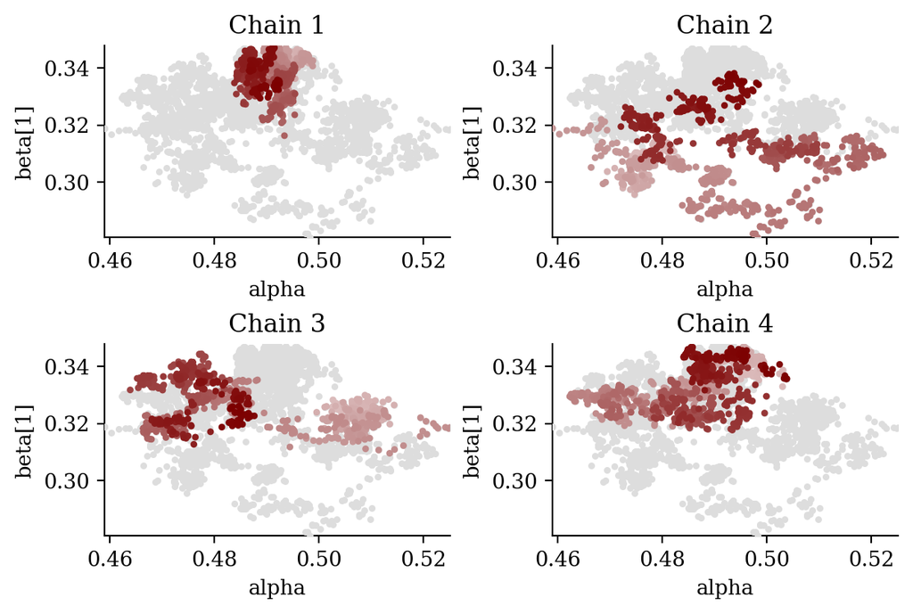

```python
util.plot_pairs_by_chain(samples['alpha'], 'alpha',
                         samples['beta[1]'], 'beta[1]')
```

To more quantitatively blame the large split $\hat{R}$s on these strong autocorrelations we can plot the split $\hat{R}$ from each expectand against the corresponding empirical effective sample size. Specifically for each expectand we plot split $\hat{R}$ against we use the smallest empirical effective sample size of the four Markov chains.

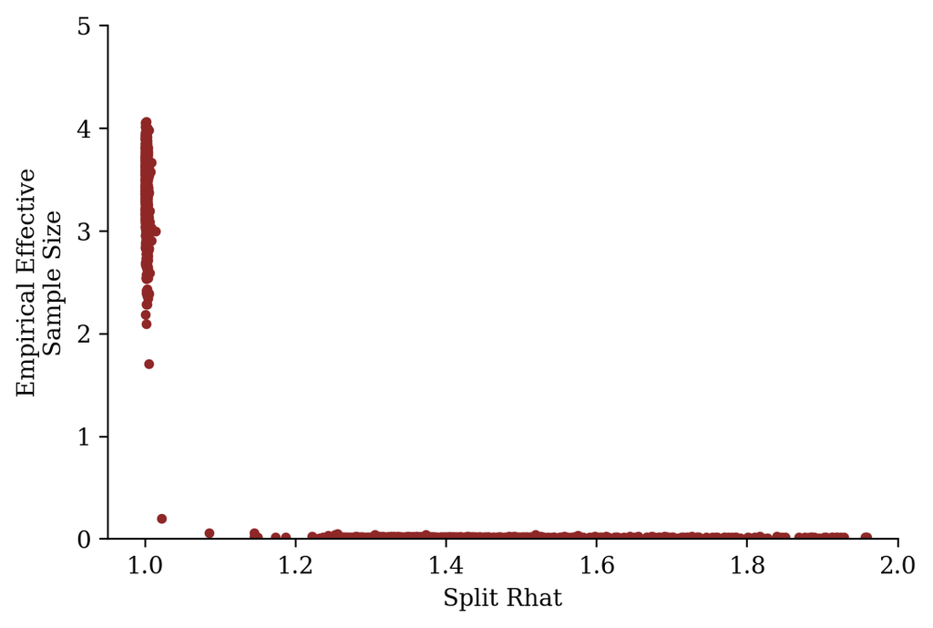

```python
rhats = util.compute_split_rhats(samples)
min_eesss = util.compute_min_eesss(samples)

plot.scatter(rhats, min_eesss, color=dark, s=10)
plot.gca().set_xlim([0.95, 2])
plot.gca().set_xlabel("Split Rhat")
plot.gca().set_ylim([0, 5])
plot.gca().set_ylabel("Empirical Effective\nSample Size")
plot.gca().spines["top"].set_visible(False)
plot.gca().spines["right"].set_visible(False)

plot.show()
```

If we are sloppy, ignore these diagnostics, and assume that all of our Markov chain Monte Carlo estimators are accurate then we are quickly mislead about the actual behavior of the posterior distribution. One way to guard against this sloppiness is to always accompany a Markov chain Monte Carlo estimator with an estimated error. Even if that error is inaccurate it can sometimes communicate underlying problems.

For example let’s look at a pushforward histogram for each parameter with light gray bands visualizing twice the standard error around the bin probability estimates in dark red.

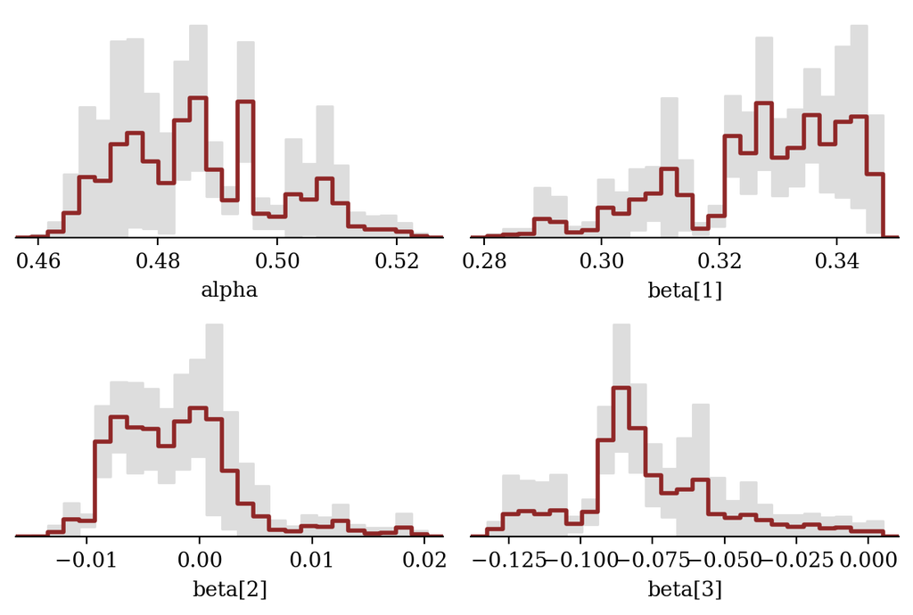

```python
f, axarr = plot.subplots(2, 2, layout="constrained")

util.plot_expectand_pushforward(axarr[0, 0], samples['alpha'],
                                25, display_name='alpha')
util.plot_expectand_pushforward(axarr[0, 1], samples['beta[1]'],
                                25, display_name='beta[1]')
util.plot_expectand_pushforward(axarr[1, 0], samples['beta[2]'],
                                25, display_name='beta[2]')
util.plot_expectand_pushforward(axarr[1, 1], samples['beta[3]'],
                                25, display_name='beta[3]')

plot.show()
```

Reducing the number of bins decreases the relative standard errors but at the same time many of the visual artifacts recede.

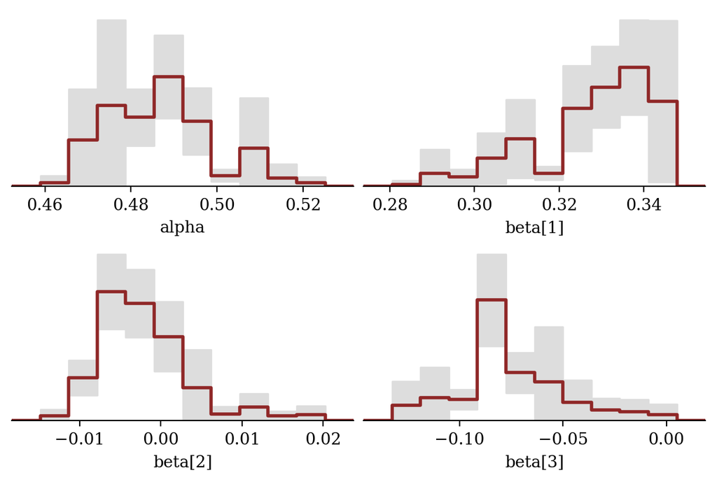

```python
f, axarr = plot.subplots(2, 2, layout="constrained")

util.plot_expectand_pushforward(axarr[0, 0], samples['alpha'],
                                10, display_name='alpha')
util.plot_expectand_pushforward(axarr[0, 1], samples['beta[1]'],
                                10, display_name='beta[1]')
util.plot_expectand_pushforward(axarr[1, 0], samples['beta[2]'],
                                10, display_name='beta[2]')
util.plot_expectand_pushforward(axarr[1, 1], samples['beta[3]'],
                                10, display_name='beta[3]')

plot.show()
```

When the bin indicator functions enjoy Markov chain Monte Carlo central limit theorems these standard error bands allow us to discriminate between meaningful structure and accidental artifacts regardless of the histogram binning. Even if central limit theorems don’t hold the error bands provide one more way that we can potentially diagnose untrustworthy computation.

# License

The code in this case study is copyrighted by Michael Betancourt and licensed under the new BSD (3-clause) license:

https://opensource.org/licenses/BSD-3-Clause

The text and figures in this case study are copyrighted by Michael Betancourt and licensed under the CC BY-NC 4.0 license:

https://creativecommons.org/licenses/by-nc/4.0/

# Original Computing Environment

```python
from watermark import watermark
print(watermark())
```

```
Last updated: 2024-04-30T20:27:40.639857-04:00

Python implementation: CPython
Python version       : 3.9.6
IPython version      : 8.3.0

Compiler    : Clang 12.0.0 (clang-1200.0.32.29)
OS          : Darwin
Release     : 23.4.0
Machine     : x86_64
Processor   : i386
CPU cores   : 16
Architecture: 64bit
```

```python
print(watermark(packages="matplotlib,numpy,pystan,scipy"))
```

```
matplotlib: 3.5.2
numpy     : 1.22.3
pystan    : 2.19.1.1
scipy     : 1.8.0
```